# Module 3: Pop. Health & Delivery Innovations

MHIA 6160 | Value & Quality in Healthcare | 1.50 | W27

Dr. Cameron B. Chiarot

## Module 3.1

### Equity vs. Equality Frameworks & Empirical Measurement

## Defining Equity & Equality

**Equality (Input Focus)**

- **Define:** Providing the exact same resources/interventions for the population.
- **Assumption:** Uniform treatment equals fairness.
- **Limitation:** Ignores pre-existing structural disparities (e.g. travel).

**Equity (Outcome Focus)**

- **Define:** Allocating resources, opportunities, and support proportional to need.
- **Assumption:** Fairness requires personalized allocation.
- **Advantage:** Neutralizes structural disadvantage to achieve systemic parity.

**Question**

In a publicly funded healthcare system, what is an example of Equity & Equality?

## The Moral & Economic Imperative

**The System Lens (Public Mandates)**

- **Moral Obligation:** Upholding social justice, human rights, and the pillars of the CHA.
- **Population Resilience:** Preventing chronic disease clustering in vulnerable groups.
- **Policy Goal:** Ensuring universal accessibility translates into realized health gains.

**The Industry Lens (Private Efficiency)**

- **Fin. Incentives:** Depend on government-backed funding (e.g., insurance).
- **Risk & Cost Contain.:** Health disparities drive high costs that strain budgets.
- **Viability:** Aligning private delivery with population health needs.

**Case Preview: LifeLabs & Diagnostic Access**

Consider a private provider like LifeLabs: core blood work is publicly funded, but specialized tests require OOP payment unless covered by private insurance. How does this mixed-payer model impact equity? (To be explored in Section 3.3).

## Deconstructing the Terminology

**Universal Set (Disparities / Inequalities)**

- **Broad Scope:** *All* observed or measured differences in health between groups.
- **Includes:** Unavoidable genetic variations & avoidable social differences.
- **Key Takeaway:** Documentation without moral judgment.

**Strict Subset (Inequities)**

- **Scope:** Subset of disparities that are systematic, socially produced, & avoidable.
- **Excludes:** Purely natural or genetic that policy cannot change.
- **Key:** $\text{Inequities} \subset \text{Disparities}$ (Every inequity is a disparity, but not every disparity is an inequity).

**Question**

Why is it methodologically critical for researchers to separate natural biological variations from socially produced disparities before designing public policy?

## Core Framework - Definitions (Braveman, 2006)

**Health Equity & Social Advantage**

- **Ethical Principle:** Grounded in social justice and human rights.
- **Social Hierarchy:** Group status explicitly determined by wealth, power, or prestige.
- **Policy Intentionality:** Focuses on health outcomes that can be shaped by public policies.

**Health Disparities / Inequalities**

- **Systemic Harm:** Specific health differences that affect socially disadvantaged groups.
- **The Comparison Rule:** Evaluates less advantaged vs. privileged groups.
- **Accountability Goal:** Tightens definitions so governments cannot dilute equity targets.

## Core Framework - Measurement (Braveman, 2006)

**Disadvantaged Social Groups**

- **Socioeconomic Status:** Categorizing populations (e.g. poverty, wealth, & income).
- **Demographics:** Identifying disparities (e.g., race, ethnicity, & gender).
- **Geography:** Evaluating differences between regions (e.g. rural vs. urban).

**Measurable Indicators**

- **Health Outcomes:** e.g., mortality rates, life expectancy, & chronic illness.
- **Health Determinants:** e.g., housing, working conditions, & environmental exposures.
- **Healthcare Metrics:** e.g., care quality, insurance coverage, & financial protection.

## Conceptual Pathway: Disparity to Inequity

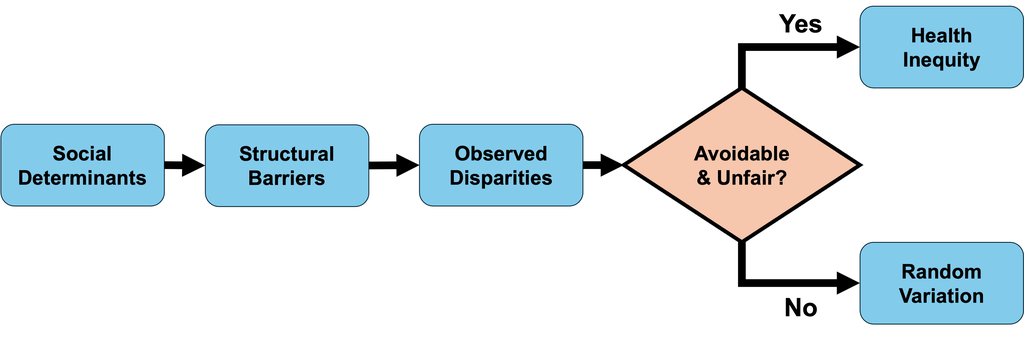

## Health Disparity vs. Health Inequity

**Health Disparities / Inequalities (Broad)**

- **Define:** Measurable diff. in health outcomes or determinants across populations.
- **Neutral Baseline:** Biological, unmeasured factors, & social differences.
- **Analytical Goal:** Documenting where the gaps exist across groups.

**Health Inequity (Unjust Subset)**

- **Define:** Subset of disparities that are systematic, socially produced, and unfair.
- **Ethical Mandate:** Rooted in principles of social justice and human rights.
- **Policy Goal:** Targeted intervention to correct structural unfairness.

## Stratification Variables in Healthcare

**Core Axes of Inequity**

- **Socioeconomic Status (SES):** Income brackets, wealth distribution, and poverty.
- **Demographics:** Race, ethnicity, gender identity, and age cohorts.
- **Geography:** Urban vs. rural distance-to-care gradients.
- **Intersectionality:** Recognize how overlapping social identities compound vulnerability.

**Analytical Purpose in R**

- **Data Disaggregation:** Move beyond aggregate population averages to identify extremes.
- **Subgroup Filtering:** Isolate vulnerable cohorts to calculate specific utilization rates.
- **Gradient Mapping:** Visualize health outcomes across economic/geographic spectrums.

## Measuring Inequality Empirically

**Absolute vs. Relative Measures**

- **Absolute Measures (e.g., Rate Difference):** Absolute magnitude of disparity.
- **Relative Measures (e.g., Rate Ratio):** Proportional disparities.
- **Complementary Role:** Both are required because absolute measures inform public health urgency, while relative measures track proportional inequity.

**Advanced Summary Metrics**

- **Concentration Index:** Degree of socioeconomic-related inequality.
- **Slopes Index of Inequality:** Estimates the absolute difference in predicted health status.
- **Empirical Utility:** Converts visual health gradients into standardized, comparable numerical values.

## Quantifying Inequality: Key Formulas

**Absolute Rate Difference (RD)**

- **Formula:** $RD = Y_{\text{disadvantaged}} - Y_{\text{privileged}}$
- **Interpretation:** Measures the direct absolute gap in health outcomes between groups.
- **Use Case:** Crucial for public health planning to assess the abs. volume of excess burden.

**Relative Rate Ratio (RR)**

- **Formula:** $RR = \frac{Y_{\text{disadvantaged}}}{Y_{\text{privileged}}}$
- **Interpretation:** Proportional risk or rate of occurrence relative to a reference.
- **Use Case:** Essential for comparing disparities across different outcomes.

## Visualizing Disparities in R

**The Code-Along Philosophy**

- **Data Literacy:** Use standardized `ggplot2` pipelines.
- **Stratified Visuals:** Translate raw data into charts, boxplots, or gradient curves.
- **Exposing Gradients:** Visuals reveal hidden inequities that aggregate metrics hide.

**R Workflow & Syntax Preview**

- **Data Filtering:** Grouping by socioeconomic quintiles or geographic regions.
- **Aesthetic Mapping:** Assigning axes to utilization rates and filling by status.
- **Reproducibility:** Use `.Rproj` and `.Rmd` scripts to ensure transparent reporting.

**Question**

Why is visualizing a data gradient often more persuasive to a non-technical executive board than presenting a table of raw regression coefficients?

## Example: Visualizing a Gradient in R

**Sample Code (`ggplot2` Pipeline)**

````markdown
```{r}
library(tidyverse)

# Plotting healthcare utilization by income quintile
ggplot(data_df, aes(x = income_quintile,
                    y = utilization_rate,
                    fill = income_quintile)) +
  geom_bar(stat = "identity", alpha = 0.8) +
  labs(
    title = "Primary Care Visits by Income Quintile",
    x = "Socioeconomic Quintile",
    y = "Visits per 1,000 Population"
  ) +
  theme_minimal()
```
````

**Key Pedagogical Takeaways**

- **Transparent Pipelines:** Data manipulation translates directly into visual evidence.
- **Exposing Gradients:** Bar height differences immediately communicate the gradient.
- **Reproducibility:** Highlights the link between raw analytical data frames.

## System Lens: Public Mandates & Universal Coverage

**The Public Sector Perspective**

- **Core Mandate:** Legislation to decouple healthcare from individual purchasing power.
- **Canada Health Act (CHA):** Anchored on the five pillars.
- **Regional Health Authorities:** Organize and distribute resources geographically.

**Neutralizing Socio-Economic Gradients**

- **Universal Entitlement:** Ensure services are allocated based on need not income.
- **Structural Limitations:** Recognize where public universal coverage falls short.
- **Equity Challenge:** How the system disproportionately affects the marginalized.

**Question**

What are some examples where the current public coverage falls short?

## Industry Lens: Private Innovation & Market Access

**The Private Sector Perspective**

- **Market-Driven Innovation:** Leveraging private capital, advanced medical technology, and operational efficiency to expand service capacity.
- **Alternative Delivery Models:** Private diagnostic clinics, specialized surgical centres, and fee-for-service options supplementing public capacity.
- **Speed and Convenience:** Offering faster access for individuals able to pay out-of-pocket or via private insurance.

**Equity Implications & Risks**

- **Widening Inequity Gaps:** e.g., Divert scarce clinical talent and resources.
- **Socio-Economic Stratification:** e.g., Create a two-tier system.
- **Targeted Public-Private Solutions:** e.g., Private delivery models for underserved.

## Key Takeaways

- **Equality of Input:** Distributing resources, funding, or services uniformly across all populations (treating everyone the same).
- **Equity of Outcome:** Allocating resources proportionally based on underlying need to achieve fair health outcomes (treating people justly).
- **The Leadership Pitfall:** Mistaking equal resource allocation for fair delivery when baseline vulnerabilities differ.
- **Disaggregate the Data:** Reject aggregate population averages; always stratify utilization and outcome metrics by key variables (e.g. SES).
- **Bridge Public and Private:** Ensure that efficiency and private innovation solve structural delivery gaps rather than entrenching two-tier access.

## Module 3.2

### Patient-Centred vs. Population-Centred Care

## Defining the Spectrum

**Patient-Centric Care**

- **Focus:** The disease, clinical encounter, and individual (i.e, patient).
- **Goal:** Optimize clinical outcomes, treatment adherence, and disease management.
- **Primary Agent:** The clinician/care team (guidance through a care pathway).

**Person-Centric (or Person-Centred) Care**

- **Focus:** The whole person, including social determinants, *beyond* diagnosis.
- **Goal:** Holistic well-being and align interventions with individual need.
- **Primary Agent:** A collaborative partnership (i.e., person is the expert).

**Core Evolution**

The evolution from disease management to holistic well-being.

## The Operational Shift

| Dimension | Patient-Centric Approach | Person-Centric Approach |
| --- | --- | --- |
| **Primary Question** | *“What is the matter with this patient?”* | *“What matters to this person?”* |
| **Decision-Making** | Shared decision-making focused on treatment options. | Co-production of care aligned with life goals & social context. |
| **Scope of Health** | Disease mngmt. & clinical metric targets (e.g., BP). | Quality of life & lived experience. |
| **System Design** | Streamlined clinical workflows and navigate care continuum. | Integrated systems bridging medicine, public health, & community. |

## Practical Application: A Case Contrast

**The Scenario:** A 68-year-old; severe COPD & type 2 diabetes; repeated hospital visits.

**Patient-Centric Lens**

- **Focus:** Fix the clinical delivery.
- **Action:** Optimize medication regimens, improving inhaler technique, & education.

**Person-Centric Lens**

- **Focus:** Addressing the human context.
- **Action:** Assessing housing conditions, food security, & support personal goals.

**Key Takeaway**

Patient-centricity fixes the *delivery of care*; person-centricity addresses the *context of the human life*.

## Operationalizing Person-Centric Care: Potential Solutions

**Redesigning Workflows & Incentives**

- **Team-Based Care:** Shift administrative and social screening burdens away from physicians by integrating social workers and navigators.
- **Realigning Incentives:** Move away from pure fee-for-service toward value-based care models that reward long-term functional well-being.

**Digital Health & Culture Shift**

- **Digital Health & PROMs:** Use digital intake tools to capture “what matters to me” and incorporate PROMs/PREMs into EHRs.
- **Training & Culture:** Train clinicians in active listening and active humility, shifting success from “curing disease” to “enabling goals.”

## Discussion Question

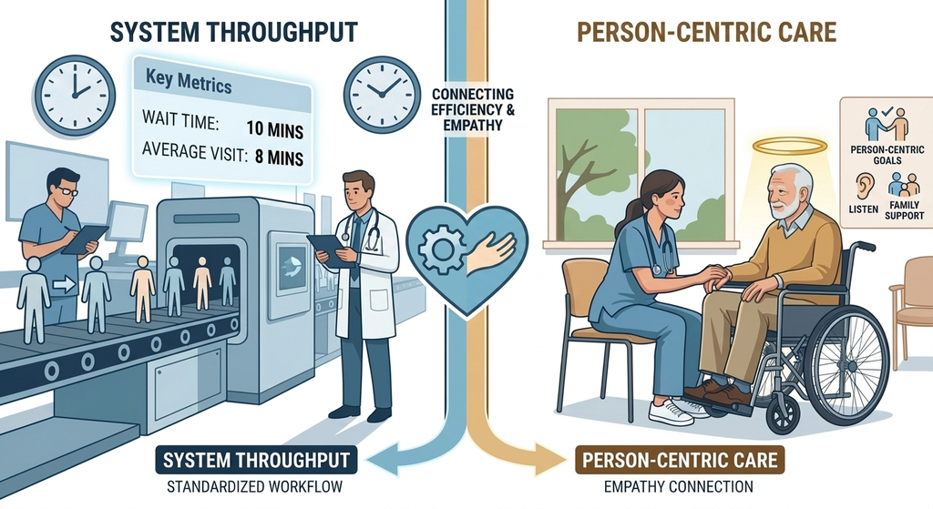

**Class Discussion**

In resource-constrained healthcare systems, how do we operationalize person-centric care without overwhelming clinical workflows built primarily for patient-centric throughput?

## Discussion Answer Key: Operationalizing Person-Centric Care

**The Systemic Challenge**

- **Throughput Pressures:** Traditional fee-for-service models penalize time spent exploring “what matters” versus processing patient volume.
- **Workflow Friction:** Clinicians face severe burnout when expected to address social determinants of health without structural, team-based support.

**Administrative Solutions**

- **Structural Integration:** Offloading social screening to multidisciplinary team members protects clinician time while preserving human context.
- **Value-Based Alignment:** Financial models must reward holistic functional outcomes rather than just procedural volume to make person-centric care sustainable.

**Key Leadership Takeaway**

Sustaining person-centric care requires moving beyond healthcare provider expertise; it demands system-level redesign that aligns operational workflows with what matters most to the patient.

## Module 3.3

### Health Service Delivery Models (Value-Based)

## Institutional Governance: Hospitals & MSAAs

**Governance vs. Ownership**

- **Government Ownership & Funding:** Hospitals are public assets.
- **The Mechanism:** Accountability through Multi-Service Accountability Agreements (MSAAs) between health authorities & hospital boards.
- **Arm’s-Length Operation:** Does not manage day-to-day operations; this is delegated to boards & admin. civil servants.

**True Public Healthcare Architecture**

- **Board Autonomy:** Hospital leadership manages staffing, clinical workflows, and localized capital while meeting provincially mandated performance targets.
- **System Coordination:** MSAAs bind institutional behaviour to macro public health objectives, balancing local efficiency with regional mandates.

## Primary Care & The Ownership Spectrum

**Family Medicine: Private Practice Model**

- **Ownership Structure:** Independently owned & operated business.
- **Operational Autonomy:** Physician-led mngmt. of workflows, staff, & overhead.
- **Core Mandate:** 100% publicly insured services despite the private business.

**The Commercial Interface (e.g., LifeLabs)**

- **Mixed-Payer Model:** Delivers both publicly insured services & private/OOP testing.
- **Commercial Divergence:** Private, for-profit across a consumer retail health market.
- **Structural Tension:** Navigating between public and commercial efficiency.

**Leadership Insight**

Distinguishing between independent public-service practices and commercial mixed-payer entities is vital for managing equity, access, and CHA pillars.

## Defining Value-Based Healthcare vs. Volume-Based Delivery

**Traditional Volume-Based Care**

- **Focus:** Maximizing patient throughput, visit counts, and procedural volumes.
- **Incentive:** Fee-for-service rewards *quantity* of services versus health recovery.
- **Consequence:** Siloed, fragmented, & escalating costs without proportional health gains.

**Value-Based Healthcare (VBHC)**

- **Focus:** Optimizing health outcomes relative to the total costs.
- **Incentive:** Aligning financial remuneration with sustained health recovery.
- **Consequence:** Streamlined point-of-care and elimination of waste & low-value interventions.

**Core Equation**

$$\text{Value} = \frac{\text{Health Outcomes Achieved}}{\text{Costs of Delivering Outcomes}}$$

## Structural Delivery Innovations: Integrated Practice Units (IPUs)

**Structural Characteristics**

- **Condition-Focused:** Dedicated to managing the full cycle of care for a specific medical condition or primary care segment.
- **Multidisciplinary Teams:** Co-locating physicians, nurses, pharmacists, and allied health professionals under one roof.
- **Dedicated Facilities:** Streamline workflows & diagnostic resources for target patient populations.

**Value Generation Mechanics**

- **Reduced Fragmentation:** Minimizes administrative hand-offs & delays between disconnected departments.
- **Accelerated Learning:** Routine outcome tracking allows care teams to refine protocols.
- **Single-Point Accountability:** Establishes responsibility for the entire care continuum.

## Case Study: LifeLabs in a Mixed-Payer Model

**The LifeLabs Operational Model**

- **Commercial Structure:** A private, for-profit operating across retail health markets.
- **Core Public Interface:** Delivers publicly insured lab. testing funded through prov. health insurance plans.
- **Private Service Expansion:** Offers specialized testing; OOP payment or private insurance.

**Strategic Equity & Access Implications**

- **Mixed-Payer Tension:** Examine how public & private shapes service availability.
- **Access Disparities:** Examine whether private expansion creates a two-tier system where ability-to-pay alters speed.
- **Leadership Application:** Evaluate the balance of private efficiency with CHA pillars.

## Dual-Lens Analysis & R-Code Efficiency Frontiers

**Dual-Lens Strategic Perspective**

- **System Lens (Public Mandates):** Evaluate how delivery models protect CHA pillars.
- **Industry Lens (Private Innovation):** Assess how private-sector operational agility and data analytics can trim clinical waste and compress length-of-stay.

**R-Workflow & Efficiency Mapping**

- **Visualizing Value:** Translate data into cost-outcome efficiency frontiers.
- **Code-Along Script Preview:** Plot provider cost-per-episode vs. PROMS.
- **Leadership Tool:** Reproducible `ggplot2` pipelines to identify delivery outliers.

**Code Preview**

````markdown
```{r}
ggplot(ip_performance_df, aes(x = total_episode_cost, y = recovery_score,
                              color = delivery_model)) +
  geom_point(size = 3) + geom_smooth(method = "lm")
```
````

## Module 3 Summary: Pop. Health & Delivery Innovations

- **Macro-to-Micro Alignment:** Effective healthcare leadership requires understanding how government funding pipelines constrain point-of-care delivery options.
- **Governance Clarity:** Recognize the distinct structural boundaries between true public hospital governance and independent private practices.
- **Condition-Centric Delivery:** Transition away from fragmented, volume-driven silos toward IPUs organized around the full cycle of care.
- **Navigating Mixed-Payer Markets:** Address the equity and access tensions highlighted by private models operating at the intersection of public insurance and private OOP.
- **Data-Driven Execution:** Utilize R and standardized visualization pipelines to monitor cost-outcome efficiency frontiers & drive evidence-based health system decisions.

## Week 4 Deliverable: R-Visualization (**Weight: 15%**)

**R-Based Visualizations Due (Week 4)**

- **Weight:** 15% of final course grade.
- **Format:** 2 R-generated figures, accompanied by a 200-word insight (400 words total).
- **Core Prompts:** Methodology, Rationale, Insights, and Strategic Recommendations.

**Key Requirements & Submission**

- **Technical Execution:** Clean, commented R script (`.Rmd`) that runs without errors.
- **Data Integrity:** Appropriate scaling, professional palettes, etc.
- **Style:** Executive reporting standards.

**Full Requirements**

Refer to the course outline.